# Looking at covariates

Katia de Paiva Lopes Raj Lab Department of Neuroscience Icahn School of Medicine at Mount Sinai NYC, New York

2021-03-26

> Microglia samples | PD and CT

```r
work_dir = "~/pd-omics/katia/MyND/mynd_rev1/microglia_PDxCT/"
expression_dir = "~/pd-omics/katia/MyND/mynd_rev1/microglia_PDxCT/"
metadata_path = "~/pd-omics/katia/MyND/mynd_rev1/microglia_PDxCT/join_metadata/"
```

```r
load(paste0(metadata_path, "metadata_PD_CT_mic.Rdata"))

# Transforms characters columns in factors columns
indx <- sapply(join_metadata, is.character)
join_metadata[indx] <- lapply(join_metadata[indx], function(x) as.factor(x))
join_metadata$ph = as.numeric(as.character(join_metadata$ph))
# str(join_metadata) #shows class for all columns
```

## HM: correlating the covariates

“Evaluating the correlation between variables in a important part in interpreting variancePartition results. When comparing two **continuous** variables, Pearson correlation is widely used. But variancePartition includes **categorical** variables in the model as well. In order to accommodate the correlation between a continuous and a categorical variable, or two categorical variables we used canonical correlation analysis. **Canonical Correlation Analysis (CCA)** is similar to correlation between two vectors, except that CCA can accommodate matricies as well.” Gabriel Hoffman.

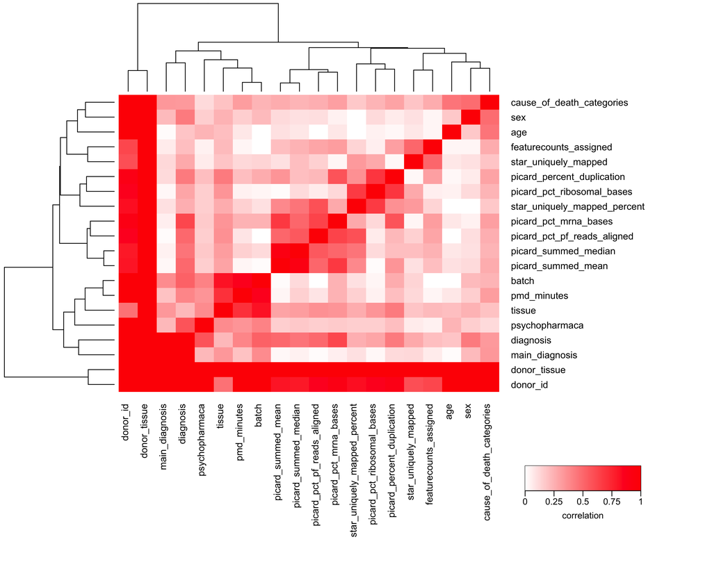

```r
#form <- as.formula(paste("", paste(colnames(join_metadata), collapse=" + "), sep=" ~ ")) #form contains the design

form <- ~ batch + donor_id + donor_tissue + diagnosis + main_diagnosis +
    age + sex + tissue + cause_of_death_categories +
    picard_pct_mrna_bases + picard_pct_pf_reads_aligned +
    picard_pct_ribosomal_bases + picard_percent_duplication +
    picard_summed_mean + picard_summed_median + pmd_minutes +
    psychopharmaca + star_uniquely_mapped + star_uniquely_mapped_percent +
    featurecounts_assigned

C = variancePartition::canCorPairs(form, join_metadata)

# pdf(paste0(work_dir, "figures_pdf/canonical_hm.pdf"), width = 10, height = 8)
plotCorrMatrix(C, margins = c(15,18))
# dev.off()
```

### Donors with 01 tissue

```r
### Number of tissues by donor
tissuesBydonor = rowSums(table(join_metadata[,c("donor_id","tissue")]))
# createDT(as.data.frame(tissuesBydonor))

sum(rowSums(table(join_metadata[,c("donor_id","tissue")]))==1)
```

[1] 17

```r
donor1sample = names(which(rowSums(table(join_metadata[,c("donor_id","tissue")]))>1))
donor1sample
```

[1] “14-005” “14-015” “14-029” “14-051” “14-069” “14-075” “14-078” “15-018” [9] “15-024” “15-055” “15-087” “15-089” “16-016” “16-027” “16-046” “16-056” [17] “16-067” “16-078” “16-080” “16-116” “16-137” “17-003” “17-005” “17-012” [25] “17-016” “17-078” “17-097” “17-124” “18-018” “18-021” “18-064” “18-105” [33] “18-112” “MG-03” “MG-04” “MG-06” “MG-08” “MG-09” “MG-12” “MG-13” [41] “MG-14” “MG-15” “MG-19” “MG-20” “MG-22” “MG-25” “MG-26”

## Input expression

```r
load(paste0(expression_dir, "expression_data/mic_pd_ct_filt.Rdata"))
dim(counts1) #17489   154
```

[1] 17489 154

## VP: 154 samples

If the covariate have NAs in the column, we can’t fit a model for Limma or Dream.

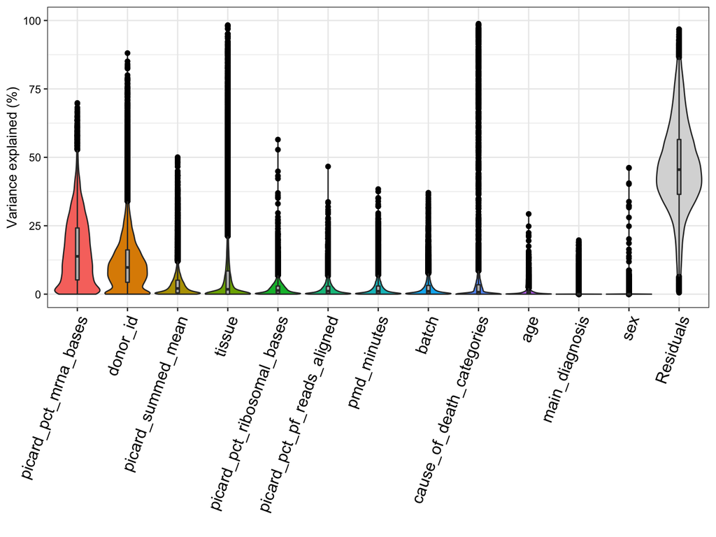

```r
# library(doParallel)
# cl <- makeCluster(4)
# registerDoParallel(cl)
#
# form <- ~ (1|donor_id) + age + (1|tissue) + (1|main_diagnosis) + (1|sex) + pmd_minutes + picard_pct_mrna_bases + picard_summed_mean + picard_pct_pf_reads_aligned +  picard_pct_ribosomal_bases + (1|cause_of_death_categories) + batch
#
# varPart_tx <- suppressWarnings( fitExtractVarPartModel( counts1, form, join_metadata) )
#
# save(varPart_tx, file = paste0(work_dir, "varPart_tx_pd_ct.RData"))

load(paste0(work_dir, "varPart_tx_pd_ct.RData"))
vp <- sortCols( varPart_tx )

# pdf(paste0(work_dir, "figures_pdf/vp_pd_ct.pdf"), width = 8, height = 6)
plotVarPart(vp) +
  ggeasy::easy_rotate_x_labels(angle = 70, side = c("right"))
# dev.off()
```

R version 3.6.2 (2019-12-12) Platform: x86_64-apple-darwin15.6.0 (64-bit) Running under: macOS 10.16

Matrix products: default BLAS: /Library/Frameworks/R.framework/Versions/3.6/Resources/lib/libRblas.0.dylib LAPACK: /Library/Frameworks/R.framework/Versions/3.6/Resources/lib/libRlapack.dylib

locale: [1] en_US.UTF-8/en_US.UTF-8/en_US.UTF-8/C/en_US.UTF-8/en_US.UTF-8

attached base packages: [1] stats4 parallel stats graphics grDevices utils datasets [8] methods base

other attached packages: [1] forcats_0.4.0 stringr_1.4.0  
[3] dplyr_1.0.2 purrr_0.3.4  
[5] readr_1.3.1 tidyr_1.1.2  
[7] tibble_3.0.4 tidyverse_1.3.0  
[9] broom_0.5.6 edgeR_3.28.0  
[11] DESeq2_1.26.0 SummarizedExperiment_1.16.1 [13] DelayedArray_0.12.3 BiocParallel_1.20.1  
[15] matrixStats_0.57.0 GenomicRanges_1.38.0  
[17] GenomeInfoDb_1.22.0 IRanges_2.20.1  
[19] S4Vectors_0.24.4 pamr_1.56.1  
[21] survival_3.1-8 cluster_2.1.0  
[23] factoextra_1.0.6 gplots_3.1.0  
[25] ggfortify_0.4.10 variancePartition_1.17.7  
[27] Biobase_2.46.0 BiocGenerics_0.32.0  
[29] scales_1.1.1 foreach_1.4.8  
[31] limma_3.42.0 ggplot2_3.3.2